# PeerAssignment 1

James Primrose

11/08/2018

### What is mean total number of steps taken per day?

- For this part of the assignment, you can ignore the missing values in the dataset.
- Make a histogram of the total number of steps taken each day
- Calculate and report the mean and median total number of steps taken per day / aggregate to get total steps per day

Load the data

```r
old.par <- par(mfrow=c(1,1))
act  <- read.csv("activity.csv",head=T,sep=",")
```

Take a peek at the data

```r
head(act)
```

```
##   steps       date interval
## 1    NA 2012-10-01        0
## 2    NA 2012-10-01        5
## 3    NA 2012-10-01       10
## 4    NA 2012-10-01       15
## 5    NA 2012-10-01       20
## 6    NA 2012-10-01       25
```

Aggregate steps per day

```r
per.day <- aggregate(steps ~ date, data=act,FUN=sum,na.rm=TRUE)
s <- per.day$steps
```

Grab the mean & median

```r
smean <- mean(s)
smed <- as.numeric(median(s))
```

Make Histogram and format

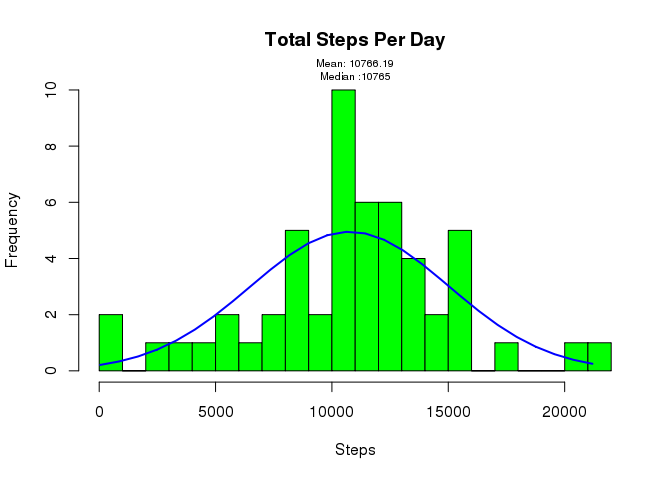

```r
b <- as.numeric(nrow(per.day))/2
h <- hist(s,breaks=b,main="Total Steps Per Day",xlab="Steps",col="green")
sfit<-seq(min(s),max(s),length=b)
yfit<-dnorm(sfit,mean=smean,sd=sd(s))
yfit <- yfit*diff(h$mids[1:2])*length(s)
lines(sfit, yfit, col="blue", lwd=2)
tout <- paste("Mean: ",round(smean,d=2),"\nMedian :",smed,sep="")
mtext(tout, 3,-.25,cex=.65)
```

The mean total steps per day is 10766.19 The mediam total steps per day is 10765

Cleanup

```r
rm(per.day,b,h,s,sfit,smean,smed,tout,yfit)
```

### What is the average daily activity pattern?

- Make a time series plot (i.e. type = “l”) of the 5-minute interval (x-axis) and the average number of steps taken, averaged across all days (y-axis).
- Which 5-minute interval, on average across all the days in the dataset, contains the maximum number of steps?

Take a look again at the same data

```r
head(act)
```

```
##   steps       date interval
## 1    NA 2012-10-01        0
## 2    NA 2012-10-01        5
## 3    NA 2012-10-01       10
## 4    NA 2012-10-01       15
## 5    NA 2012-10-01       20
## 6    NA 2012-10-01       25
```

Aggregate for mean steps per interval

```r
avg.day <- aggregate(steps ~ interval, data=act,FUN=mean,na.rm=TRUE)
```

Pull in the mean of aggregated means

```r
smean <- mean(avg.day$steps)
```

Get the max interval value

```r
smax <- subset(avg.day,avg.day$steps==max(avg.day$steps))
```

Plot away w/abline & mtext

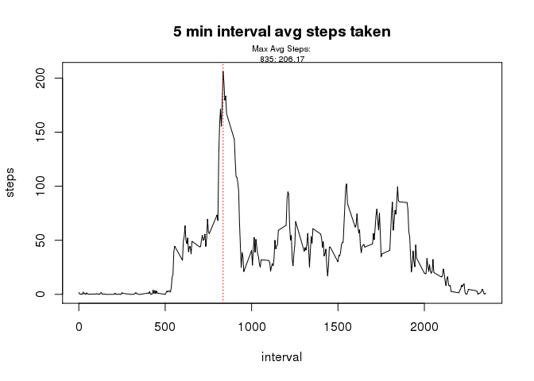

```r
plot(avg.day, type="l",xlab="interval",lty=1,main="5 min interval avg steps taken",cex=.5)
abline(v=smax$interval,col="red",lty=3,cex=1)
mtext(paste("Max Avg Steps: \n",smax$interval,": ",round(smax$steps,d=2),sep=""), 3,-.15,cex=.65)
```

The 08:35 interval, on average across all days, contains the most number of steps at 206.17 steps.

Cleanup

```r
rm(avg.day,smax,smean)
```

### Imputing missing values

- Note that there are a number of days/intervals where there are missing values (coded as NA). The presence of missing days may introduce bias into some calculations or summaries of the data.
- Calculate and report the total number of missing values in the dataset (i.e. the total number of rows with NAs)
- Devise a strategy for filling in all of the missing values in the dataset. The strategy does not need to be sophisticated. For example, you could use the mean/median for that day, or the mean for that 5-minute interval, etc.
- Create a new dataset that is equal to the original dataset but with the missing data filled in.

Look at the data

```r
head(act)
```

```
##   steps       date interval
## 1    NA 2012-10-01        0
## 2    NA 2012-10-01        5
## 3    NA 2012-10-01       10
## 4    NA 2012-10-01       15
## 5    NA 2012-10-01       20
## 6    NA 2012-10-01       25
```

get a number of blank (NA) rows using nrow

```r
nan <- as.numeric(nrow(subset(act,is.na(act$steps))))
```

Print

```r
print(paste("The total number of missing values in the dataset is ",nan,sep=""))
```

```
## [1] "The total number of missing values in the dataset is 2304"
```

Duplicate the data for safety

```r
act2 <- act
```

Replace NA with zero (0)

```r
act2[is.na(act2)] <- 0
```

Aggregate the average steps per interval.

```r
avg.interval <- aggregate(steps ~ interval, data=act2,FUN=mean)
```

Brute force subset to split off non-zero

```r
zer <- subset(act2,act2$steps==0)
nzer <- subset(act2,act2$steps>0)
```

Merge the avg per interval

```r
zer <- merge(zer,avg.interval, by="interval")
zer <- zer[c(1,3,4)]
```

Reorder

```r
zer <- zer[c(3,2,1)]
names(zer) <- c("steps", "date",  "interval")
```

Rbind the final set and display the new data set

```r
final.act <- rbind(nzer,zer)
head(final.act)
```

```
##     steps       date interval
## 555   117 2012-10-02     2210
## 556     9 2012-10-02     2215
## 627     4 2012-10-03      410
## 631    36 2012-10-03      430
## 644    25 2012-10-03      535
## 647    90 2012-10-03      550
```

Cleanup

```r
rm(act2,avg.interval,zer,nzer,nan)
```

Aggregate to get total steps per day

```r
per.day <- aggregate(steps ~ date, data=final.act,FUN=sum,na.rm=TRUE)
s <- per.day$steps
```

Grab the mean & median

```r
smean <- mean(s)
smed <- as.numeric(median(s))
```

Make a histogram

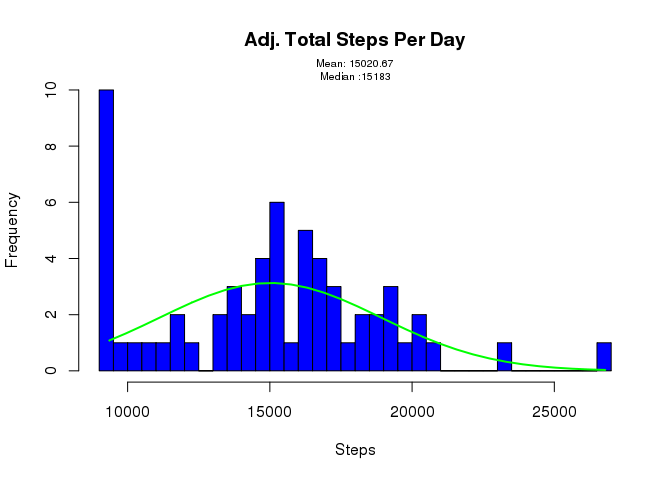

```r
b <- as.numeric(nrow(per.day))/2
h <- hist(s,breaks=b,main="Adj. Total Steps Per Day",xlab="Steps",col="blue")
sfit<-seq(min(s),max(s),length=b)
yfit<-dnorm(sfit,mean=smean,sd=sd(s))
yfit <- yfit*diff(h$mids[1:2])*length(s)
lines(sfit, yfit, col="green", lwd=2)
tout <- paste("Mean: ",round(smean,d=2),"\nMedian :",smed,sep="")
mtext(tout, 3,-.25,cex=.65)
```

Q. Do these values differ from the estimates from the first part of the assignment?

Q. What is the impact of imputing missing data on the estimates of the total daily number of steps?

Cleanup

```r
rm(per.day,b,h,old.par,s,sfit,smean,smed,tout,yfit)
```

### Are there differences in activity patterns between weekdays and weekends?

For this part the weekdays() function may be of some help here. Use the dataset with the filled-in missing values for this part.

One more look at the data

```r
head(final.act)
```

```
##     steps       date interval
## 555   117 2012-10-02     2210
## 556     9 2012-10-02     2215
## 627     4 2012-10-03      410
## 631    36 2012-10-03      430
## 644    25 2012-10-03      535
## 647    90 2012-10-03      550
```

1 - Create a new factor variable in the dataset with two levels – “weekday” and “weekend” indicating whether a given date is a weekday or weekend day.

```r
final.act$wd <- factor(weekdays(as.Date(final.act$date,'%Y-%m-%d')))
levels(final.act$wd) <- c("Weekday","Weekday","Weekend","Weekend","Weekday","Weekday","Weekday")
```

2 - Make a panel plot containing a time series plot (i.e. type = “l”) of the 5-minute interval (x-axis) and the average number of steps taken, averaged across all weekday days or weekend days (y-axis). See the README file in the GitHub repository to see an example of what this plot should look like using simulated data.

Whack up the data into weekend and weekday

```r
final.act.end <- subset(final.act,final.act$wd=="Weekend")
final.act.end <- final.act.end[with(final.act.end, order(date,interval)),]
per.end <- aggregate(steps ~ interval, data=final.act.end,FUN=mean,na.rm=TRUE)

final.act.day <- subset(final.act,final.act$wd=="Weekday")
final.act.day <- final.act.day[with(final.act.day, order(date,interval)),]
per.day <- aggregate(steps ~ interval, data=final.act.day,FUN=mean,na.rm=TRUE)
```

Set our graphing parms to be tiny / narrow margin, give a bit of space right for our top yaxis and maybe some mtext blurbs & Plot

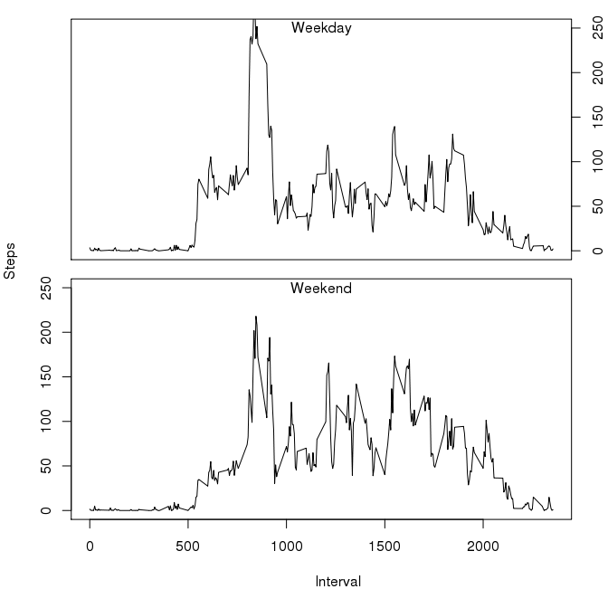

```r
par(mfrow = c(1,1),
          oma = c(5,4,0,0) + 0.05,
          mar = c(0,0,1,2) + 0.05)
par(fig=c(0,1,0,0.5))
plot(per.end$steps ~ per.end$interval,type="l",ylim=c(0,250))
mtext("Weekend",3,-1)
par(fig=c(0,1,0.5,1), new=TRUE)
plot(per.day$steps ~ per.day$interval,xaxt="n",yaxt="n",type="l",ylim=c(0,250))
axis(side=4)
mtext("Weekday",3,-1)
title(xlab = "Interval",
      ylab = "Steps",
      outer = TRUE, line = 3)
```

Cleanup

```r
old.par <- par(mfrow=c(1,1))
rm(act, final.act, final.act.day, final.act.end, per.day, per.end, old.par)
```